# Technology and Social Change

Lecture 3: Ancient Societies and Technology

Bogdan G. Popescu

bgpopescu@tec.mx

Tecnológico de Monterrey

# Part 1: Motivating Puzzles

## Why No Sustained Growth in Ancient Societies?

Rome had concrete, roads, aqueducts — then centuries of stagnation

China invented paper, printing, gunpowder — yet no industrial revolution

Mesopotamia created writing, mathematics — empires still collapsed

For ~10,000 years, most humans lived near subsistence

The “modern breakthrough” is only ~250 years old

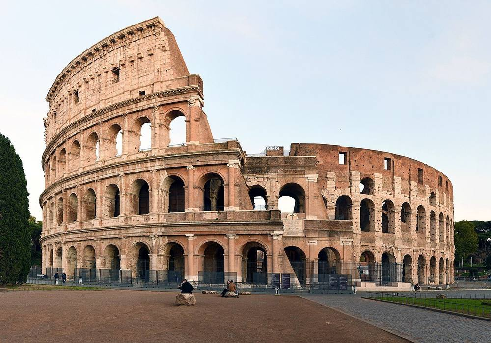

The Colosseum (c. 80 CE): engineering marvel, yet no sustained growth. Photo: FeaturedPics / Wikimedia Commons (CC BY-SA 4.0).

## The Long Stagnation: GDP Per Capita

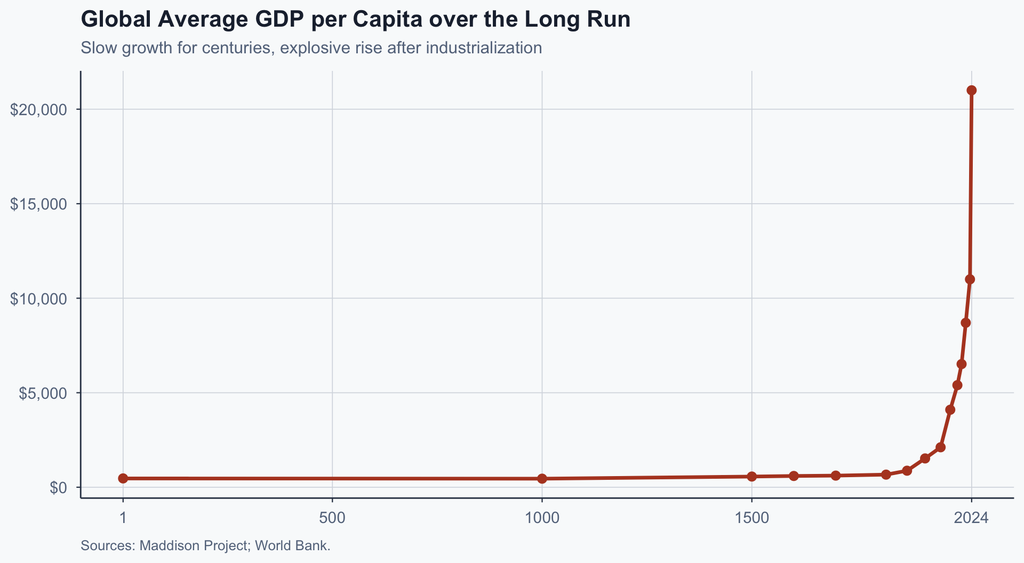

## Population Growth: Another View of Stagnation

[figure not shown]

World population over the long run. Source: Our World in Data, based on HYDE and UN Population Division.

## Guiding Questions for Today

How did political institutions emerge from forager bands?

Why do some societies innovate while others suppress technology?

What role do factor prices play in directing change?

Can we predict which societies develop growth-promoting institutions?

## Learning Objectives

By the end of this lecture, you should be able to:

1. **Define** institutions; distinguish formal vs informal constraints
2. **Explain** Boix’s producer–looter model of state formation
3. **Apply** Allen’s induced innovation hypothesis to cases
4. **Compare** Mesopotamia, Rome, and Han China
5. **Evaluate** critiques and propose empirical tests

## Roadmap

Part 1: Motivation and objectives

Part 2: Core theoretical framework (Boix + Allen + North)

Part 3: Comparative evidence (Mesopotamia, Rome, China)

Part 4: Critiques, alternatives, discussion

# Part 2: Core Theoretical Framework

## What Are Institutions? (North, 1990)

> “Humanly devised constraints that structure political, economic, and social interaction”

**Formal rules**: constitutions, laws, property rights

**Informal constraints**: customs, traditions, norms, taboos

**Enforcement**: courts, social sanctions, reputation

Institutions reduce uncertainty and transaction costs (the costs of negotiating, monitoring, and enforcing exchanges beyond the price itself)

## Two Institutional Archetypes (Acemoglu & Robinson, 2012)

**Inclusive**

- Broad property-rights protection
- Participation and contestation
- Rewards innovation (“creative destruction” — new innovations displacing old firms and methods)

**Extractive**

- Power concentrated in elites
- Extraction from many to few
- Suppresses creative destruction

## The Boix Model: Producers vs Looters (2015)

Forager societies: egalitarian, mobile, low storage

The **Neolithic revolution** (~10,000 BCE): transition from foraging to settled agriculture

Agriculture creates **localized productivity clusters**

New surplus becomes **storable** and **defensible**

Two strategies emerge: **produce** or **loot**

State emerges as protection racket *or* coordination device

## The Producer-Looter Pathways

```
%%{init: {"theme": "base", "themeVariables": {"fontSize": "22px", "primaryColor": "#e8f0ed", "primaryTextColor": "#1e293b", "primaryBorderColor": "#4a7c6f", "lineColor": "#334155"}, "flowchart": {"useMaxWidth": true, "nodeSpacing": 50, "rankSpacing": 60, "htmlLabels": true, "width": 1150, "height": …
flowchart LR
    A["Agricultural<br/>Transition"] --> B["Fixed, Storable<br/>Surplus"]
    B --> C["Predation<br/>Becomes Viable"]
    C --> D{"Produce<br/>or Loot?"}
    D -->|Produce| E["Demand for<br/>Protection"]
    D -->|Loot| F["Raiding &<br/>Extraction"]
    E --> G["State<br/>Emerges"]
    F --> G
```

Agriculture changed the **payoff structure**, not human nature (Boix, 2015)

## Case Evidence: Producer-Looter Model

[video not shown]

1. Why states emerged after the Neolithic revolution?  
2. What is the key mechanism that replaced surplus for state formation?  
3. Why are cereals easier to appropriate than roots and tubers?  
4. Why does cereal cultivation simultaneously create both the demand for a state and the means to finance it?

## Archaeological Evidence: Heights as Inequality Proxy

### Did Agriculture Make People Worse Off?

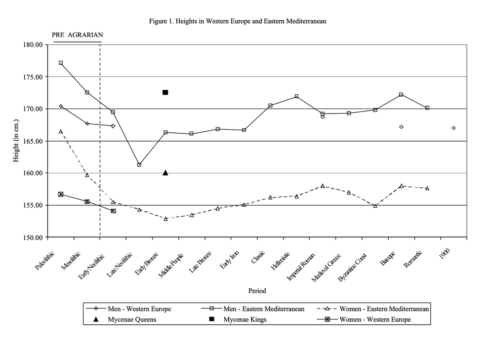

Male skeletal heights declined after the Neolithic transition. Source: Based on Angel (1984); Steckel (2008).

The height decline is consistent with the emergence of extractive hierarchies.

## The Boix Causal Framework

```
%%{init: {"theme": "base", "themeVariables": {"fontSize": "22px", "primaryColor": "#e8f0ed", "primaryTextColor": "#1e293b", "primaryBorderColor": "#4a7c6f", "lineColor": "#334155"}, "flowchart": {"useMaxWidth": true, "nodeSpacing": 40, "rankSpacing": 55, "htmlLabels": true, "width": 1150, "height": …
flowchart LR
    A["Geography<br/>& Ecology"] --> B["Surplus<br/>Concentration"]
    B --> C["Predation Risk<br/>(Producer-Looter)"]
    C --> D["State &<br/>Institutions"]
    D --> E["Security &<br/>Property Rights"]
    E --> F["Innovation<br/>Incentives"]
    F --> G["Development<br/>Outcome"]
```

Geography operates **through** institutions, not directly (Boix, 2015)

## Factor Prices and Innovation (Allen, 2009)

Innovation is not random — it responds to incentives

Inventors and firms economize on **expensive** factors

High wages → **labor-saving** innovation

Cheap energy → energy-intensive production becomes viable

Factor prices shaped by geography, institutions, and trade

## Allen’s Induced Innovation Mechanism

```
%%{init: {"theme": "base", "themeVariables": {"fontSize": "20px", "primaryColor": "#e8f0ed", "primaryTextColor": "#1e293b", "primaryBorderColor": "#4a7c6f", "lineColor": "#334155"}, "flowchart": {"useMaxWidth": true, "nodeSpacing": 40, "rankSpacing": 50, "htmlLabels": true, "width": 1100, "height": …
flowchart LR
    A["Relative<br/>Factor Prices"] --> B{"Which factor<br/>is expensive?"}
    B -->|"High Wages<br/>Cheap Energy"| C["Labor-Saving,<br/>Energy-Intensive<br/>Machines"]
    B -->|"Low Wages<br/>Cheap Labor"| D["Labor-Intensive<br/>Methods;<br/>No Mechanization"]
    B -->|"High Energy<br/>Costs"| E["Energy-Saving<br/>Technology"]
    C --> F["e.g. Britain:<br/>Steam Engine"]
    D --> G["e.g. India, China:<br/>Hand Production"]
    E --> H["e.g. Fuel-Efficient<br/>Furnaces"]
```

Same technology: rational in one price context, irrational in another (Allen, 2009)

## Allen’s High-Wage Economy Thesis

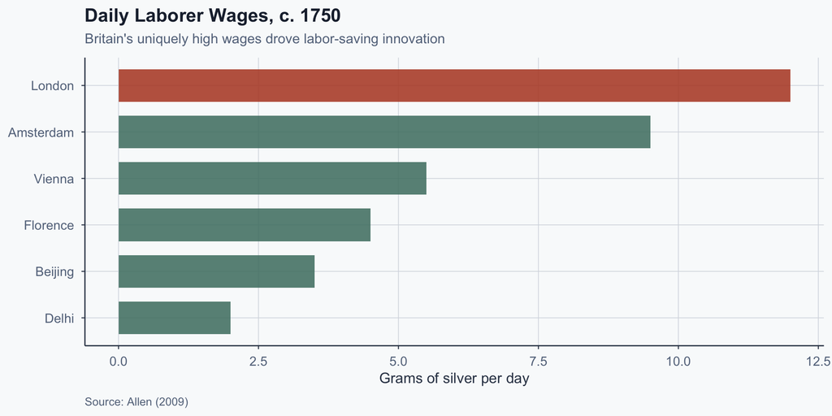

## Integrated Boix-Allen Framework

```
%%{init: {"theme": "base",
"flowchart": {"nodeSpacing": 35, "rankSpacing": 55, "htmlLabels": true}}}%%
flowchart LR

A["Geography<br/>& Climate"] --> B["Agricultural<br/>Potential"]
B --> C["Producer–Looter<br/>Dynamics"]
C --> D["Institutions<br/>(Type)"]

subgraph BOIX["Boix: Institutional Structure"]
direction TB
D --> E["Labor Systems<br/>Slavery?"]
D --> F["Property Rights<br/>Secure?"]
D --> G["Market Access<br/>Open?"]
end

E --> H
F --> H
G --> H

subgraph ALLEN["Allen: Prices → Technology"]
direction TB
H["Factor Prices"] --> I["Innovation Direction"]
I --> J["Economic Performance"]
end

%% --- FORCE LIGHT STYLING (override Reveal CSS) ---
classDef nodeLight fill:#ffffff,stroke:#94a3b8,color:#1e293b,stroke-width:1px;
classDef clusterLight fill:#ffffff,stroke:#94a3b8,color:#1e293b,stroke-width:1px;

class A,B,C,D,E,F,G,H,I,J nodeLight;

style BOIX fill:#ffffff,stroke:#94a3b8,stroke-width:1px,color:#1e293b;
style ALLEN fill:#ffffff,stroke:#94a3b8,stroke-width:1px,color:#1e293b;

%% optional: make arrows readable on dark slide backgrounds
linkStyle default stroke:#e2e8f0,stroke-width:2px;
```

Extractive institutions distort price signals → weak mechanization incentives

## State Capacity: Necessary but Not Sufficient

States can promote innovation: infrastructure, property rights

States can suppress innovation: heavy taxation, extraction

High capacity + inclusive institutions → growth

High capacity + extractive institutions → sophisticated extraction

Low capacity → limited ability to do either

## Vocabulary Check

| Term | Definition | Source |
| --- | --- | --- |
| Institutions | Rules of the game | North (1990) |
| Extractive | Power concentrated; extraction | Acemoglu & Robinson (2012) |
| Inclusive | Broad participation; property rights | Acemoglu & Robinson (2012) |
| Induced innovation | Tech responds to factor prices | Hicks (1932); Allen (2009) |
| Factor prices | Costs of production inputs (labor, capital, energy) that shape incentives to innovate | Allen (2009) |
| State capacity | A state’s ability to tax, enforce laws, and provide public goods | Besley & Persson (2011) |

## Exercise 1: Apply the Producer-Looter Model

**Prompt**: Pick a modern developing country you know well.

1. Where are the “productive clusters” located?
2. Who are the modern “looters” and how do they extract?
3. Does the state protect producers or enable extraction?
4. What does Boix’s model predict about institutional change?

**Time**: 5 minutes — discuss in pairs, then share

# Part 3: Comparative Evidence

## Three Ancient Societies, Three Paths

| Dimension | Mesopotamia | Rome | Han China |
| --- | --- | --- | --- |
| Period | ~3500–500 BCE | 509 BCE–476 CE | 206 BCE–220 CE |
| Geography | Tigris / Euphrates | Mediterranean | Yellow / Yangzi |
| Core institutions | Temple → Palace | Republic → Empire | Bureaucracy |
| Labor regime | Corvée + slavery | Massive slavery | Peasantry + corvée |
| Key innovations | Writing, irrigation | Roads, concrete | Paper, iron casting |
| Outcome | Cycles of rise/fall | Rise then decline | Long stability |

Different paths, same stagnation outcome — why?

**Corvée**: compulsory unpaid labor owed to the state, often for public works.

## Mesopotamia: Between the Rivers

[video not shown]

1. What geographic features made Mesopotamia suitable for early agricultural development?  
2. What did cuneiform originally develop to track before it became a full writing system?  
3. Name two Mesopotamian innovations in mathematics or astronomy that we still use today.

## Mesopotamia: Between the Rivers

Tigris and Euphrates: unpredictable flooding

Irrigation required collective action and coordination

High agricultural productivity concentration

Surrounded by pastoral / nomadic populations (potential looters)

Classic Boix setup: productive clusters vulnerable to predation

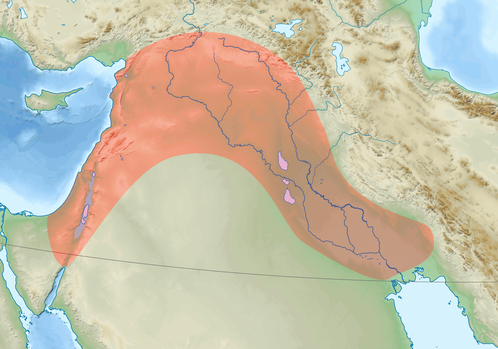

The Fertile Crescent: productive river valleys surrounded by arid steppe and desert. Source: Semhur / Wikimedia Commons (CC BY-SA 3.0).

## Mesopotamian Institutions and Innovation

Temple economy → Palace-centered kingship (*lugal*, Sumerian for “big man” or king)

Cycles: city autonomy → empire → collapse → repeat

Hammurabi’s Code: contracts, property, standardized punishment

Innovation: writing (cuneiform — wedge-shaped script pressed into clay tablets), mathematics, metallurgy

[figure not shown]

The Code of Hammurabi (c. 1750 BCE): one of the earliest written legal codes, now in the Louvre. Photo: Mbzt / Wikimedia Commons (CC BY 3.0).

## Mesopotamian Institutions and Innovation

Temple economy → Palace-centered kingship (*lugal*, Sumerian for “big man” or king)

Cycles: city autonomy → empire → collapse → repeat

Hammurabi’s Code: contracts, property, standardized punishment

Key pattern: innovation primarily **state-directed**

[figure not shown]

The Code of Hammurabi (c. 1750 BCE): one of the earliest written legal codes, now in the Louvre. Photo: Mbzt / Wikimedia Commons (CC BY 3.0).

## Rome: From Republic to Empire

Early Republic: relatively inclusive for citizens

Expansion → slaves + wealth concentration + land consolidation

Empire: increasingly extractive; weaker non-elite protections

Late Empire: administrative strain, fragmentation

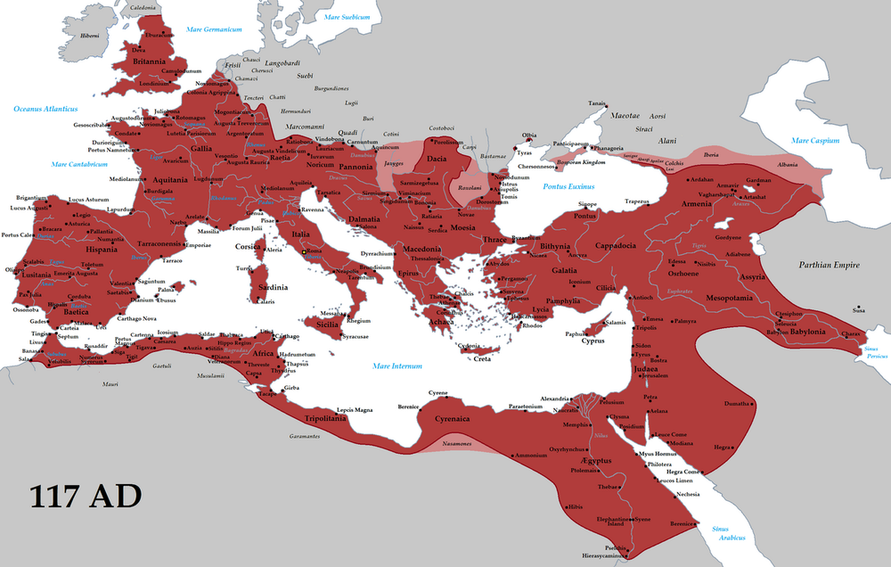

The Roman Empire at its greatest extent under Trajan (117 CE). Source: Tataryn / Wikimedia Commons (CC BY-SA 3.0).

## The Roman Paradox

Engineering feats: aqueducts, roads, concrete, heating

Agricultural improvements: plows, presses, storage

Dense trade networks across the Mediterranean

Yet: limited labor-saving mechanization

Per-capita income stagnates then declines

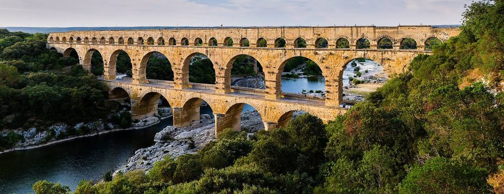

Pont du Gard, Roman aqueduct (1st c. CE). They could build this — but didn’t build labor-saving machines. Photo: Benh LIEU SONG / Wikimedia Commons (CC BY-SA 3.0).

## Why Rome Didn’t Mechanize (Allen’s Logic)

Massive slavery → very cheap labor

Allen: cheap labor → low returns to labor-saving machinery

Scheidel estimates ~30-40% of Italy’s population enslaved at peak

Why build a water mill when slaves grind grain cheaply?

Elite cultural attitudes reinforced economic incentives

## Factor Prices: Why Institutions Matter for Innovation

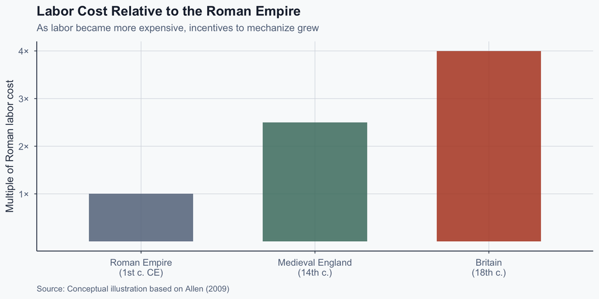

## Han China: Bureaucratic Capacity

Unified empire with sophisticated bureaucracy

Meritocratic elements (recruitment mixes recommendation + early examinations; fully competitive exam system develops later, esp. Sui/Tang/Song)

State investment: roads, canals, frontier defense

Confucian ideology: stability, hierarchy, education

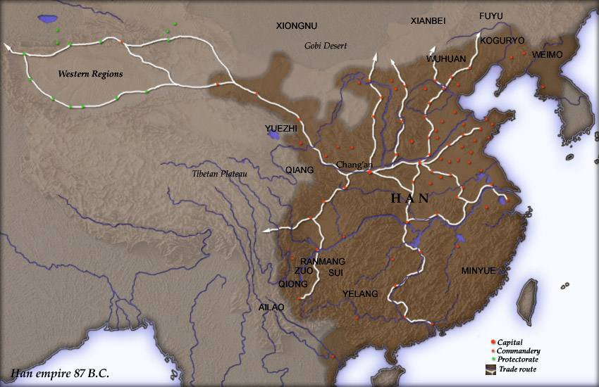

## Chinese Innovation Under the Han

Paper (improved by Cai Lun, 105 CE): transforms bureaucracy and education

Iron casting: often superior to Roman wrought iron

Agricultural tech: iron plows, rotation improvements

Water control: large-scale canal systems

Yet China also didn’t industrialize — why?

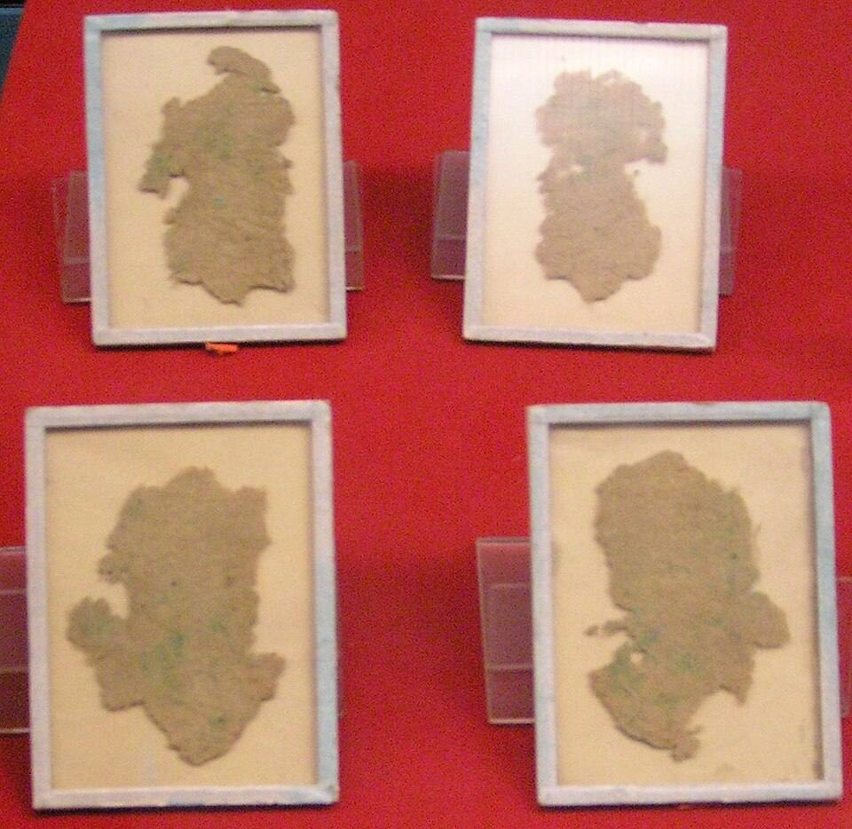

Hemp paper from the Western Han dynasty (c. 2nd–1st c. BCE), among the earliest known paper fragments. Photo: Ytrottier / Wikimedia Commons (CC BY-SA 3.0).

## The Needham Question

Joseph Needham: why no Chinese Industrial Revolution?

**Institutional**: unified empire, limited interstate competition

**Factor-price** (Allen): abundant labor → weak mechanization incentives

**Geographic** (Pomeranz): coal located far from industry

No consensus — active scholarly debate continues

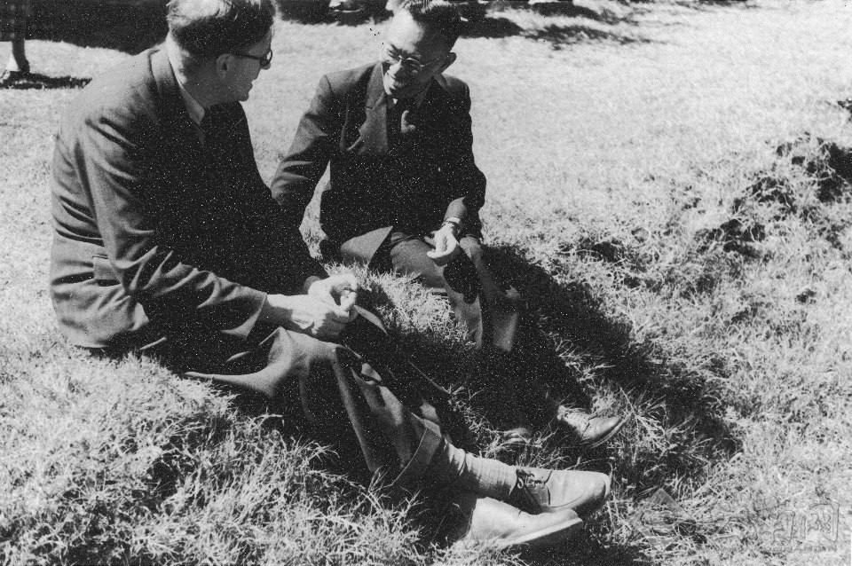

## Common Pattern Across All Three Cases

Despite different paths, all reached similar stagnation

Mesopotamia: extractive temple/palace + coerced labor

Rome: slavery → suppressed wages → weak mechanization

China: abundant labor + institutional barriers to diffusion

The Boix-Allen framework explains both achievements **and** limits

## Path Dependence and Institutional Lock-In

**Path dependence**: early choices constrain later possibilities, making institutional change costly

Institutions persist: elites defend beneficial equilibria

Extractive institutions create beneficiaries who block change

Change requires shifting bargaining power, often via shocks

**Critical junctures**: moments of upheaval (war, plague, revolution) that open windows for institutional reform

## Vocabulary Check II

| Term | Definition | Source |
| --- | --- | --- |
| Neolithic revolution | Transition from foraging to settled agriculture (~10,000 BCE) | Childe (1936) |
| Corvée | Compulsory unpaid labor owed to the state | — |
| Path dependence | Early choices constrain later possibilities | North (1990) |
| Critical junctures | Moments of upheaval that open windows for reform | Acemoglu & Robinson (2012) |
| Needham Question | Why did China not experience an Industrial Revolution? | Needham (1954–) |

# Part 4: Critiques & Discussion

## Critique 1: Geographic Determinism?

Critique: Boix overweights geography

If geography → institutions → outcomes, is geography destiny?

Response: geography shapes *parameters*, not outcomes

Same geography can yield different institutions

But: contingency may be underspecified in the model

## Critique 2: Culture and Ideas

Mokyr (2016): Enlightenment ideas enabled sustained innovation

Weber (1905): ethics and values shaped capitalism

Critique: Boix/Allen framework is too materialist

Counter: culture may be shaped by material incentives

Roman disdain for mechanics: cultural cause or economic effect?

## Critique 3: Reverse Causation

Do institutions cause growth — or does growth enable institutions?

Selection bias: successful cases attract more scholarly attention

Need **exogenous variation** (changes driven by outside forces, not by the outcome itself) to establish causality

Colonial institutions as **quasi-natural experiment** (a real-world event that mimics random assignment) (Acemoglu et al., 2001)

## Critique 4: Oversimplification

Extractive/inclusive binary can be too simplistic

China: bureaucratic + meritocratic elements (hybrid)

Rome: institutional quality varies over time and region

Need richer typologies for institutions and innovation regimes

## What Would Change My Mind?

Sustained growth under clearly extractive institutions

Stagnation despite inclusive institutions + favorable factor prices

Cultural change repeatedly preceding material change (robustly)

Successful institutional reform ignoring factor-price context

Archaeological evidence contradicting inequality–agriculture link

## Exercise 2: Evaluate the Strongest Critique

**Prompt**: Which of the four critiques do you find most compelling?

1. State your choice and give one supporting reason
2. Identify one piece of evidence that would strengthen it
3. How might Boix or Allen respond?

**Time**: 5 minutes — discuss in groups of three, then share

## Discussion Questions

Can institutions be reformed by design, or must conditions shift?

Is the US today more extractive or inclusive than in 1950?

What would Boix/Allen predict about AI and automation?

Are there “developmental states” (governments that actively direct industrial policy, e.g., South Korea, Singapore) that contradict this framework?

## References I

Acemoglu, D., & Robinson, J. A. (2012). *Why nations fail*. Crown.

Allen, R. C. (2009). *The British industrial revolution in global perspective*. Cambridge University Press.

Besley, T., & Persson, T. (2011). *Pillars of prosperity*. Princeton University Press.

Boix, C. (2015). *Political order and inequality*. Cambridge University Press.

Childe, V. G. (1936). *Man makes himself*. Watts & Co.

Hicks, J. R. (1932). *The theory of wages*. Macmillan.

## References II

Mokyr, J. (2016). *A culture of growth*. Princeton University Press.

Needham, J. (1954–). *Science and civilisation in China* (multiple volumes). Cambridge University Press.

North, D. C. (1990). *Institutions, institutional change, and economic performance*. Cambridge University Press.

Pomeranz, K. (2000). *The great divergence*. Princeton University Press.

Scheidel, W. (2019). *Escape from Rome*. Princeton University Press.

Scott, J. C. (2017). *Against the grain*. Yale University Press.